# Stock prediction LSTM Neural Network function

Marcos H. Silva

## Introduction

This method creates a LSTM neural net capable of predict a stock time series using Keras.

I wrote about LSTM and time series on [this article](https://rpubs.com/marcosmhs/rede_lstm_predicao_dolar) in RPubs site.

The code of the method could be downloaded on my [Github](https://github.com/marcosmhs/LSTM-Stock-prediction-function).

## Execution steps

The method structure could be resumed in the image bellow

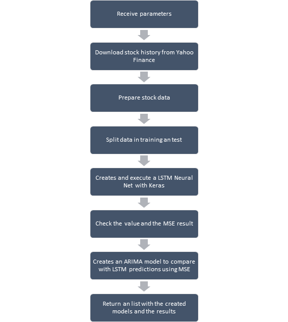

## Code Examples

Method creation:

```r
source('../lstm_stock_function.R')
```

On a first example I with use META (Facebook, WhatsApp, Instagram, etc) stocks and for now I don´t need a ARIMA comparison

```r
return_meta <-
    lstm_stock(
      stock_name = 'META',
      start_date = '2019-01-01',
      lstm_executions = 10,
      lstm_verbose = F)
```

```
## [1] "Downloading stock data..."
```

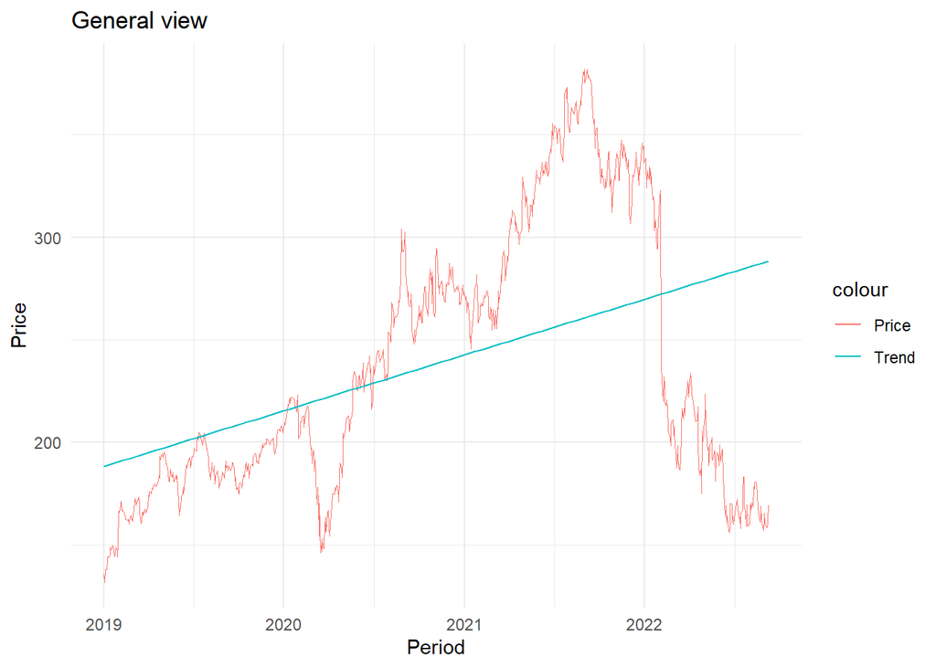

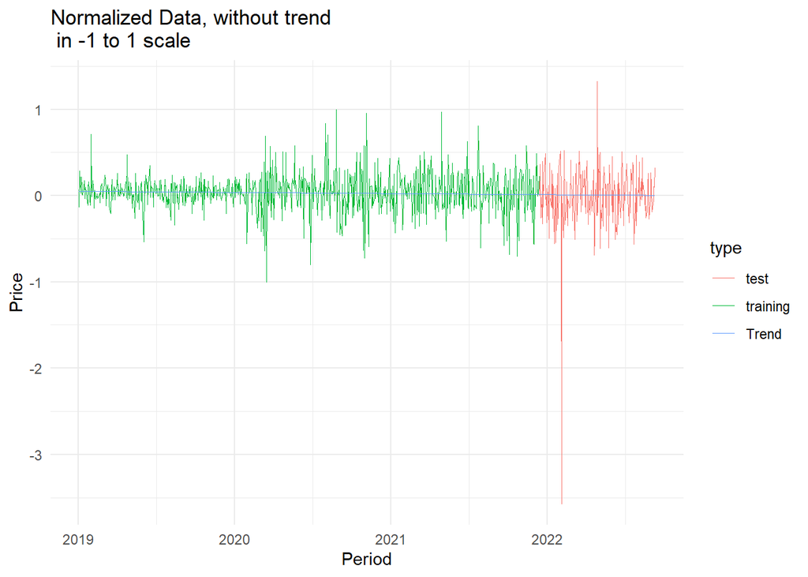

```
## [1] "fitting..."
## [1] "predicting..."
```

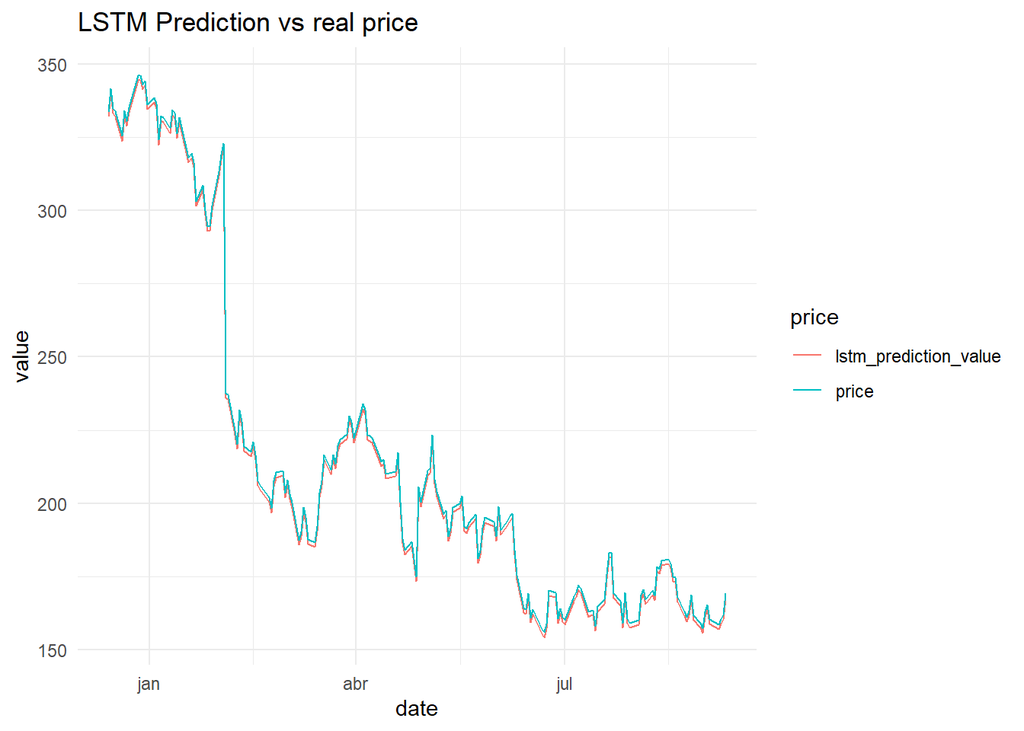

```
## [1] "MSE: 2.53399089471135"
## [1] "-----------------------------------"
## [1] "Execution completed..."
## $parameters
##   stock_name start_date   end_date arima_compare
## 1       META 2019-01-01 2022-09-12         FALSE
##
## [1] "MSE"
## # A tibble: 1 x 1
##     mse
##   <dbl>
## 1  2.53
```

On a second example the lstm_stock will use data from Petrobrás (brazilian oil company). The data will be extract from Bovespa (brazilian stock market) from 2015 until today. The method will execute a LSTM neural net with 10 iterations and in the end will also execute and ARIMA model to compare the results

```r
return_petr4 <-
    lstm_stock(
      origin = '^BVSP',
      stock_name = 'PETR4.SA',
      start_date = '2015-01-01',
      lstm_executions = 10,
      arima_compare = T,
      lstm_verbose = F)
```

```
## [1] "Downloading stock data..."
```

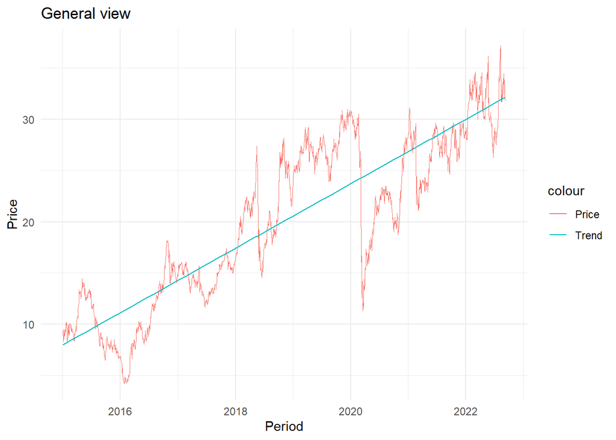

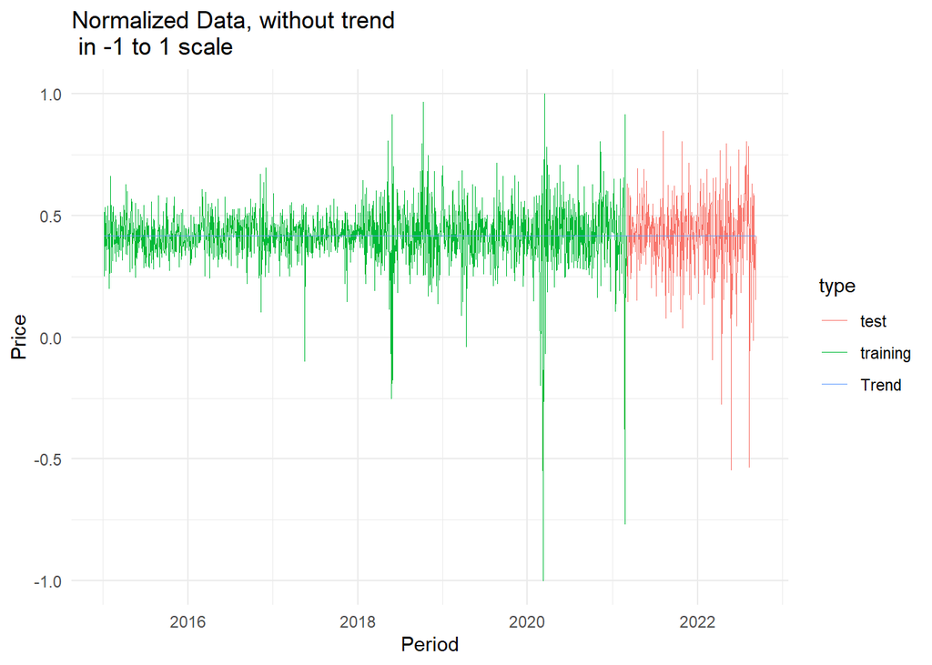

```
## [1] "fitting..."
## [1] "predicting..."
```

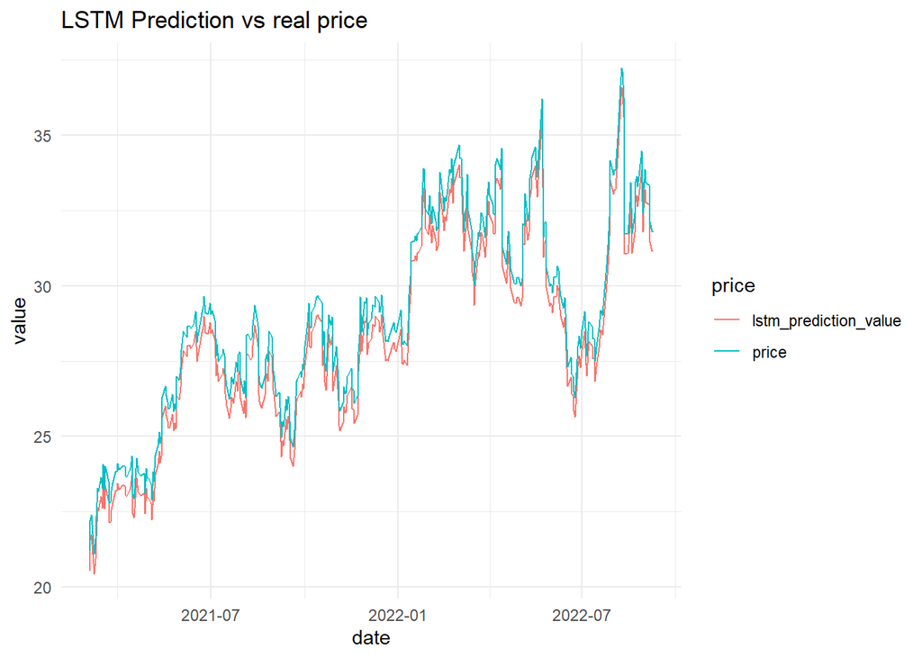

```
## [1] "MSE: 0.420328804831862"
## [1] "Starting ARIMA... "
```

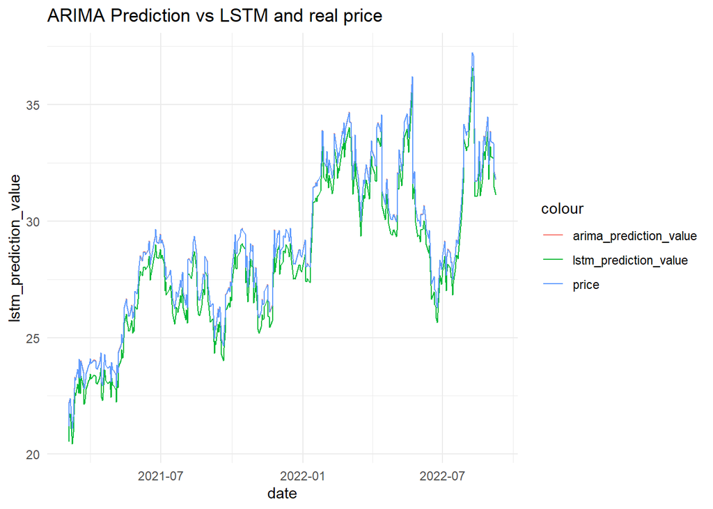

```
##   variable        value
## 1     lstm 4.203288e-01
## 2    arima 7.725121e-05
```

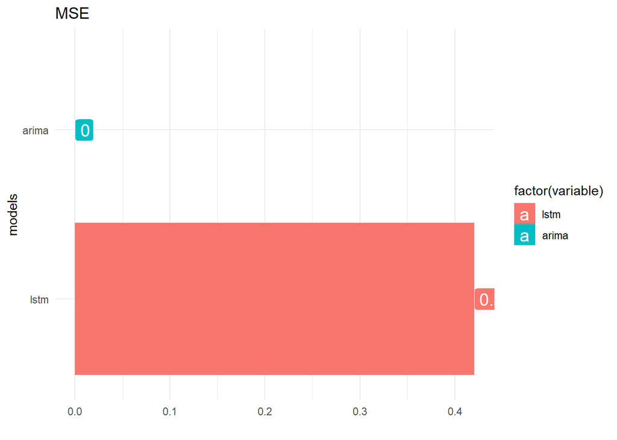

```
## [1] "-----------------------------------"
## [1] "Execution completed..."
## $parameters
##   stock_name start_date   end_date arima_compare
## 1   PETR4.SA 2015-01-01 2022-09-12          TRUE
##
## [1] "MSE"
##   variable        value
## 1     lstm 4.203288e-01
## 2    arima 7.725121e-05
```

As we can see, on this example, the ARIMA model was capable to make a better prediction comparing with the LSTM model.

To end this text, if you find some bug or “brain cramp” please e-mail me on marcosmhs@live.com and I will be glad on correct the code and register your name on the credits.